# Flyback converter

For the two-switch flyback converter shown in the figure, the input voltage is $40\,$V, and the output voltage is $10\,$V. The rated power of the converter is $10\,$W. The switching frequency is $50\,$kHz, and the turns ratio of the transformer is 2:1. The converter operates under DCM, and the secondary conduction time is one half of the off duration of the primary switches $S_1$ and $S_2$ (which are turned on or off simultaneously).

1. What is the on time of switches $S_1$ and $S_2$?
2. What is the magnetizing inductance of the flyback transformer as seen from the source side?
3. Plot the current through the primary and secondary winding, and determine the peak values.
4. Find the capacitance $C$ required to keep the output voltage ripple less than $2\,\%$.

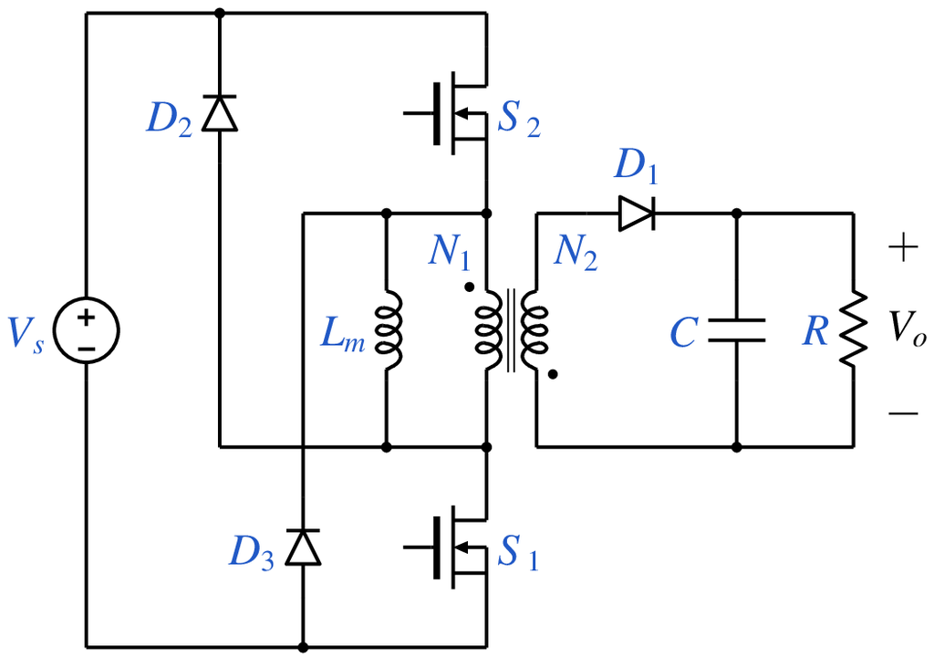

```python
from IPython.display import Image
Image(filename =r'flyback_3_fig_1.png', width=360)
```

```python
# run this cell to view the circuit file.
%pycat flyback_3_orig.in
```

We now replace the strings such as \$Vdc, \$L, with the values of our choice by running the python script given below. It takes an existing circuit file `flyback_3_orig.in` and produces a new circuit file `flyback_3.in`, after replacing \$Vdc, \$L, etc. with values of our choice.

```python
import gseim_calc as calc

P = 10.0
Vo = 10.0
R = Vo*Vo/P

s_R = ("%11.4E"%(R)).strip()

s_D = "0.25" # to be changed by user
s_Vdc = "40"
s_Lm = "40e-6" # to be changed by user
s_C = "40e-6" # to be changed by user
s_N1 = "2"
s_N2 = "1"
s_f_hz = "50e3"

T = 1/float(s_f_hz)
s_Tend = "5e-3"
delt1 = 2.0*T
Tend = float(s_Tend)
T1 = Tend - delt1
s_T1 = ("%11.4E"%(T1)).strip()

l = [
  ('$D', s_D),
  ('$Vdc', s_Vdc),
  ('$Lm', s_Lm),
  ('$R', s_R),
  ('$C', s_C),
  ('$N1', s_N1),
  ('$N2', s_N2),
  ('$f_hz', s_f_hz),
  ('$T1', s_T1),
  ('$Tend', s_Tend),
]
calc.replace_strings_1("flyback_3_orig.in", "flyback_3.in", l)
print('flyback_3.in is ready for execution')
```

```
flyback_3.in is ready for execution
```

**Execute the following cell to run GSEIM on flyback_3.in.**

```python
import os
import dos_unix
# uncomment for windows:
#dos_unix.d2u("flyback_3.in")
os.system('run_gseim flyback_3.in')
```

```
Circuit: filename = flyback_3.in
main: calling solve_trns
Transient simulation starts...
i=0
i=10000
i=20000
GSEIM: Program completed.
```

```
0
```

The circuit file (`flyback_3.in`) is created in the same directory as that used for launching Jupyter notebook. The last step (i.e., running `GSEIM` on `flyback_3.in`) creates a data file called `flyback_3.dat` in the same directory. We can now use the python code below to compute/plot the various quantities of interest.

```
filename: flyback_3.dat
peak primary current (including ILm:  4.9898E+00 A
peak-to-peak ripple in Vo:  5.6039E-01 V
duration of conduction for D1 in one cycle:  6.4211E+00 micro seconds.
```

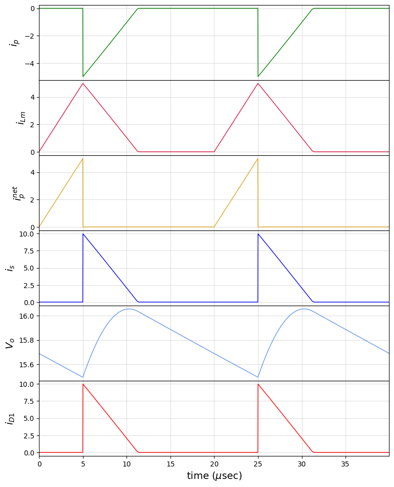

```python
import numpy as np
import matplotlib.pyplot as plt
import gseim_calc as calc
from setsize import set_size

slv = calc.slv("flyback_3.in")

i_slv = 0
i_out = 0
filename = slv.l_filename_all[i_slv][i_out]
print('filename:', filename)
u = np.loadtxt(filename)
t1 = u[:, 0]
t = t1 - t1[0]

v_out = slv.get_array_double(i_slv,i_out,"v_out",u)
ILm   = slv.get_array_double(i_slv,i_out,"ILm"  ,u)
ip    = slv.get_array_double(i_slv,i_out,"ip"   ,u)
is1   = slv.get_array_double(i_slv,i_out,"is"   ,u)
ID1   = slv.get_array_double(i_slv,i_out,"ID1"  ,u)

# since we have stored two cycles, we need to divide the last time point
# by 2 to get the period:

T = t[-1]/2

ip_net = ILm + ip

ip_net_max = max(ip_net)
print('peak primary current (including ILm:',
  "%11.4E"%(ip_net_max), 'A')

l_v_out_1 = calc.min_max_1(t, v_out, 0.0, 2.0*T)
v_out_ptop = l_v_out_1[1] - l_v_out_1[0]
print('peak-to-peak ripple in Vo:', "%11.4E"%v_out_ptop, "V")

ndiv = 5000
n_ID1 = 0

delt_ID1, ID1p = calc.interp_linear_1(t, ID1, ndiv)

for k in range(ndiv):
    if (ID1p[k] > 0): n_ID1 += 1

print('duration of conduction for D1 in one cycle:',
  "%11.4E"%(1.0e6*float(n_ID1)*delt_ID1/(2.0)), 'micro seconds.')

color1='green'
color2='crimson'
color3='goldenrod'
color4='blue'
color5='cornflowerblue'
color6='red'

fig, ax = plt.subplots(6, sharex=False)
plt.subplots_adjust(wspace=0, hspace=0.0)

set_size(7, 9, ax[0])

for i in range(6):
    ax[i].set_xlim(left=0, right=2.0*T*1e6)
    ax[i].grid(color='#CCCCCC', linestyle='solid', linewidth=0.5)

ax[0].plot(t*1e6, ip   , color=color1, linewidth=1.0, label="$i_p$")
ax[1].plot(t*1e6, ILm  , color=color2, linewidth=1.0, label="$i_{Lm}$")
ax[2].plot(t*1e6, ip_net,color=color3, linewidth=1.0, label="$i_p^{net}$")
ax[3].plot(t*1e6, is1  , color=color4, linewidth=1.0, label="$i_s$")
ax[4].plot(t*1e6, v_out, color=color5, linewidth=1.0, label="$V_o$")
ax[5].plot(t*1e6, ID1  , color=color6, linewidth=1.0, label="$i_{D1}$")

ax[0].set_ylabel(r'$i_p$'      , fontsize=14)
ax[1].set_ylabel(r'$i_{Lm}$'   , fontsize=14)
ax[2].set_ylabel(r'$i_p^{net}$', fontsize=14)
ax[3].set_ylabel(r'$i_s$'      , fontsize=14)
ax[4].set_ylabel(r'$V_o$'      , fontsize=14)
ax[5].set_ylabel(r'$i_{D1}$'   , fontsize=14)

ax[5].set_xlabel('time (' + r'$\mu$' + 'sec)', fontsize=14)

#ax[0].legend(loc = 'lower right',frameon = True, fontsize = 10, title = None,
#   markerfirst = True, markerscale = 1.0, labelspacing = 0.5, columnspacing = 2.0,
#   prop = {'size' : 12},)

for i in range(5):
    ax[i].tick_params(labelbottom=False)

#plt.tight_layout()
plt.show()
```

This notebook was contributed by **Prof. Nakul Narayanan K**, Govt. Engineering College, Thrissur. He may be contacted at nakul@gectcr.ac.in.